# hw2

Ekrem Barış Kuyucu

17 11 2021

## Introduction

In this project we are asked to use penalized regression approaches for time series representation to calculate the accuracy of fused lasso, regression tree and raw data methods. We have our CBF data and we will do some data manipulations to first find the error and lambda values, then we will plot them and finally we will find the distances between their nearest neighbours by using euclidian distance method. After finding the lambda values and MSE values, we will find the accuracy of the methods by using the calculated distances.

```r
library(data.table,quietly = TRUE,warn.conflicts = FALSE)
library(ggplot2,quietly = TRUE,warn.conflicts = FALSE)
library(repr,quietly = TRUE,warn.conflicts = FALSE)
library(rpart,quietly = TRUE,warn.conflicts = FALSE)
library(rattle,quietly = TRUE,warn.conflicts = FALSE)
library(TSrepr,quietly = TRUE,warn.conflicts = FALSE)
library(zoo,quietly = TRUE,warn.conflicts = FALSE)
library(genlasso,quietly = TRUE,warn.conflicts = FALSE)
library(e1071,quietly = TRUE,warn.conflicts = FALSE)
library(MLmetrics,quietly = TRUE,warn.conflicts = FALSE)
library(shiny,quietly = TRUE,warn.conflicts = FALSE)
library(manipulateWidget,quietly = TRUE,warn.conflicts = FALSE)
library(TSclust,quietly = TRUE,warn.conflicts = FALSE)
```

We read our data with fread function. We do some data manipulation to understand the data easier.

```r
dataset='CBF'
train_data=fread("D:/Boğaziçi/İe48b/hw2/CBF_TRAIN.txt")
head(train_data[,c(1:10)])
```

```
##    V1         V2         V3          V4          V5         V6         V7
## 1:  1 -0.4642765 -0.5550479 -0.84284310 -0.86589548 -0.9363963 -0.8172700
## 2:  1 -0.8969721 -0.6856855 -1.35138180 -1.45866680 -1.1653456 -1.4039293
## 3:  1 -0.4646960 -0.5677389 -0.03202276 -0.63504562 -0.6028255 -0.2668563
## 4:  3 -0.1871897 -0.6208077 -0.81566070 -0.52139796 -0.7904229 -0.9675174
## 5:  2 -1.1360166 -1.3191953 -1.84462380 -0.78869178 -0.2517154 -1.4876032
## 6:  2 -0.5687087 -0.8881180 -0.04797658 -0.03803611 -0.4830683 -1.0946887
##            V8          V9        V10
## 1: -0.2636122 -1.25804830 -1.2503934
## 2: -1.8217996 -0.83160109 -1.0163124
## 3: -0.2670613 -0.93104230 -0.4493819
## 4: -1.4870063 -0.27788714 -0.8350747
## 5: -0.6687641 -0.34036037 -1.0463815
## 6: -0.9534529 -0.03000688 -0.7954546
```

```r
setnames(train_data,"V1","class")
train_data[,id:=1:.N]
head(train_data)
```

```
##    class         V2         V3          V4          V5         V6         V7
## 1:     1 -0.4642765 -0.5550479 -0.84284310 -0.86589548 -0.9363963 -0.8172700
## 2:     1 -0.8969721 -0.6856855 -1.35138180 -1.45866680 -1.1653456 -1.4039293
## 3:     1 -0.4646960 -0.5677389 -0.03202276 -0.63504562 -0.6028255 -0.2668563
## 4:     3 -0.1871897 -0.6208077 -0.81566070 -0.52139796 -0.7904229 -0.9675174
## 5:     2 -1.1360166 -1.3191953 -1.84462380 -0.78869178 -0.2517154 -1.4876032
## 6:     2 -0.5687087 -0.8881180 -0.04797658 -0.03803611 -0.4830683 -1.0946887
##            V8          V9        V10         V11        V12        V13
## 1: -0.2636122 -1.25804830 -1.2503934 -0.91830825 -0.9221023 -0.9844883
## 2: -1.8217996 -0.83160109 -1.0163124 -0.80353040 -1.2595048 -1.1392341
## 3: -0.2670613 -0.93104230 -0.4493819 -0.72134200 -0.3972719 -0.9621259
## 4: -1.4870063 -0.27788714 -0.8350747  0.05059104 -0.8111683 -1.2260083
## 5: -0.6687641 -0.34036037 -1.0463815 -0.31221353 -1.0314417 -1.2005780
## 6: -0.9534529 -0.03000688 -0.7954546 -0.51445458 -0.7187614 -0.5162723
##           V14        V15        V16         V17        V18        V19
```

[output cut: 132 more lines]

## 1 1D Fused Lasso

We will select lambda parameters for each time series. We will use cross validation approach to find the desired lambda values. Our cross validation table here gives us useful information about lambda values for future use.

```r
train_data_1=melt(train_data,id.vars=c('id','class'))
train_data_1[,time:=as.numeric(gsub("\\D", "", variable))-1]
train_data_1=train_data_1[,list(id,class,time,value)]
train_data_1=train_data_1[order(id,time)]
head(train_data_1,20)
```

```
##     id class time      value
##  1:  1     1    1 -0.4642765
##  2:  1     1    2 -0.5550479
##  3:  1     1    3 -0.8428431
##  4:  1     1    4 -0.8658955
##  5:  1     1    5 -0.9363963
##  6:  1     1    6 -0.8172700
##  7:  1     1    7 -0.2636122
##  8:  1     1    8 -1.2580483
##  9:  1     1    9 -1.2503934
## 10:  1     1   10 -0.9183083
## 11:  1     1   11 -0.9221023
## 12:  1     1   12 -0.9844883
## 13:  1     1   13 -1.2880511
## 14:  1     1   14 -1.1434600
## 15:  1     1   15 -1.0488611
## 16:  1     1   16 -0.3653858
## 17:  1     1   17 -0.6913952
## 18:  1     1   18 -0.9805502
## 19:  1     1   19 -0.9913360
## 20:  1     1   20 -0.8870867
```

```r
min_lambda=list()
fused_lasso=list()
trend_table=trendfilter(as.numeric(train_data[1,-1]),ord= 0)
trend_table
```

```
##
## Call:
## trendfilter(y = as.numeric(train_data[1, -1]), ord = 0)
##
## Output:
## Path model with 128 total steps.
```

```r
cross_validation_table=cv.trendfilter(trend_table,k=10)
```

```
## Fold 1 ... Fold 2 ... Fold 3 ... Fold 4 ... Fold 5 ... Fold 6 ... Fold 7 ... Fold 8 ... Fold 9 ... Fold 10 ...
```

```r
cross_validation_table
```

```
## $err
##    34.997    27.227     5.657     4.262     3.428      2.74     2.159     1.912
## 0.9999555 0.9212235 0.1945928 0.1785446 0.1708389 0.1656369 0.1623605 0.1609429
##     1.791     1.627     1.286     1.167     1.136     0.911     0.744      0.71
## 0.1602006 0.1594004 0.1577697 0.1573646 0.1572611 0.1565877 0.1567434 0.1569617
##     0.588     0.551     0.537     0.509     0.507      0.49     0.485     0.475
## 0.1581921 0.1585478 0.1586998 0.1591134 0.1591484 0.1594587 0.1595673 0.1597559
##     0.471     0.465     0.434     0.429     0.413     0.405     0.387     0.379
## 0.1598215 0.1599581 0.1608769 0.1610107 0.1614160 0.1616063 0.1620106 0.1622459
##     0.367     0.346     0.337     0.335     0.304     0.279     0.263     0.256
## 0.1626245 0.1630945 0.1633142 0.1633929 0.1643764 0.1650998 0.1656603 0.1659477
##     0.253     0.242     0.241     0.234     0.234     0.214     0.211     0.209
## 0.1660703 0.1665768 0.1666304 0.1670187 0.1670336 0.1681416 0.1682986 0.1684732
##     0.203     0.203       0.2     0.195     0.187     0.185     0.181     0.164
## 0.1688459 0.1688725 0.1690473 0.1694273 0.1700172 0.1702297 0.1705250 0.1718915
##     0.163     0.161      0.15     0.146     0.145     0.141     0.141     0.139
## 0.1720088 0.1721497 0.1729607 0.1732880 0.1733939 0.1737667 0.1737820 0.1739670
##     0.126     0.124      0.12     0.119     0.117     0.117     0.117     0.116
## 0.1750399 0.1752855 0.1756341 0.1757826 0.1759739 0.1759898 0.1760454 0.1761232
##     0.112     0.106     0.104     0.103     0.102       0.1     0.097     0.095
## 0.1766673 0.1774330 0.1777300 0.1777885 0.1778977 0.1782097 0.1786947 0.1789279
##     0.091      0.09     0.087     0.087     0.086      0.08     0.078     0.075
## 0.1795610 0.1796938 0.1800484 0.1801335 0.1801804 0.1809337 0.1811035 0.1814727
##     0.075     0.073     0.072      0.07     0.064     0.059     0.058     0.058
## 0.1815028 0.1818014 0.1818474 0.1820871 0.1831000 0.1839092 0.1840589 0.1840820
##     0.058     0.057     0.056     0.052     0.051     0.051     0.048     0.045
## 0.1842000 0.1842517 0.1844895 0.1851008 0.1852840 0.1853563 0.1858043 0.1862757
##     0.045     0.041      0.04     0.039     0.035     0.033     0.032     0.029
## 0.1863653 0.1870091 0.1870708 0.1873607 0.1880008 0.1884215 0.1886373 0.1891101
##     0.029     0.025      0.02     0.017     0.016     0.016     0.011      0.01
## 0.1891152 0.1898121 0.1905921 0.1909588 0.1911096 0.1911104 0.1919558 0.1921221
##      0.01     0.008     0.005     0.004     0.004     0.002     0.002     0.002
## 0.1921973 0.1925105 0.1929390 0.1931692 0.1931970 0.1934970 0.1935251 0.1935848
##
## $se
##     34.997     27.227      5.657      4.262      3.428       2.74      2.159
## 0.05835988 0.05739956 0.03656629 0.03659510 0.03684048 0.03705315 0.03728962
##      1.912      1.791      1.627      1.286      1.167      1.136      0.911
## 0.03735001 0.03739994 0.03750337 0.03758051 0.03752180 0.03751259 0.03770770
##      0.744       0.71      0.588      0.551      0.537      0.509      0.507
```

[output cut: 67 more lines]

```
##
## $lambda.1se
## [1] 4.262145
##
## $i.min
## [1] 14
##
## $i.1se
## [1] 4
##
## $call
## cv.trendfilter(object = trend_table, k = 10)
##
## attr(,"class")
## [1] "cv.trendfilter" "list"
```

```r
lambda_values=data.table(cbind(cross_validation_table$err,cross_validation_table$lambda))
setnames(lambda_values,"V1","Error")
setnames(lambda_values,"V2","Lambda values")
head(lambda_values,20)
```

```
##         Error Lambda values
##  1: 0.9999555    34.9969068
##  2: 0.9212235    27.2266051
##  3: 0.1945928     5.6566203
##  4: 0.1785446     4.2621451
##  5: 0.1708389     3.4276272
##  6: 0.1656369     2.7404497
##  7: 0.1623605     2.1591004
##  8: 0.1609429     1.9124595
##  9: 0.1602006     1.7908464
## 10: 0.1594004     1.6268980
## 11: 0.1577697     1.2858650
## 12: 0.1573646     1.1673084
## 13: 0.1572611     1.1358147
## 14: 0.1565877     0.9110324
## 15: 0.1567434     0.7435113
## 16: 0.1569617     0.7098496
## 17: 0.1581921     0.5879265
## 18: 0.1585478     0.5505448
## 19: 0.1586998     0.5366989
## 20: 0.1591134     0.5087666
```

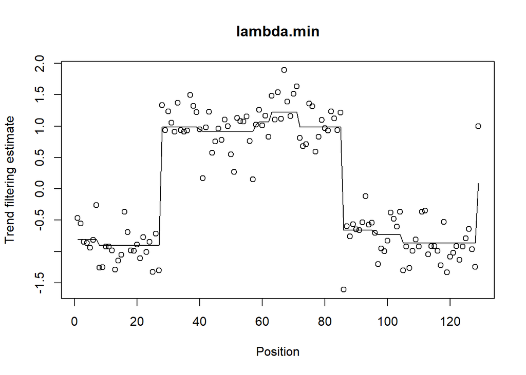

```r
plot(trend_table,lambda=cross_validation_table$lambda.min,main="lambda.min")
```

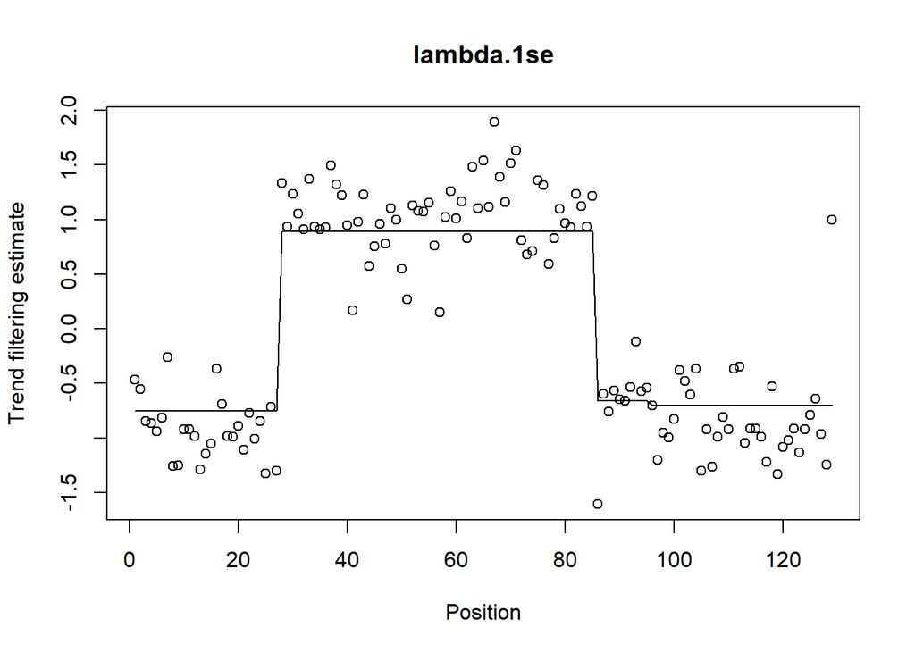

```r
plot(trend_table,lambda=cross_validation_table$lambda.1se,main="lambda.1se")
```

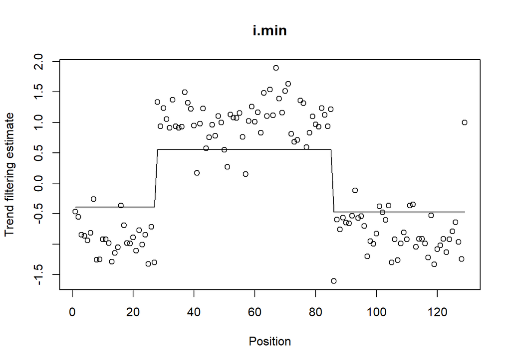

```r
plot(trend_table,lambda=cross_validation_table$i.min,main="i.min")
```

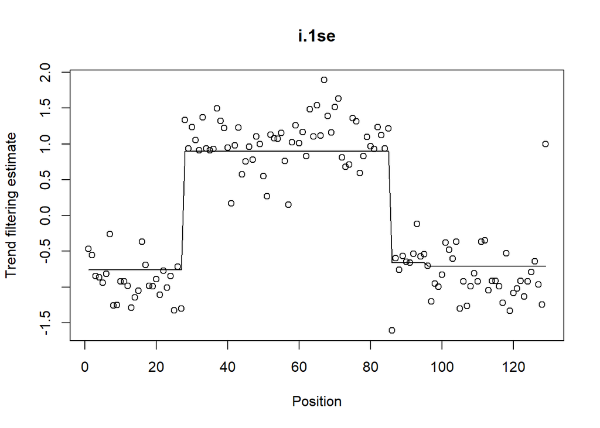

```r
plot(trend_table,lambda=cross_validation_table$i.1se,main="i.1se")
```

```r
for (i in 1:30) {
    f_lasso=fusedlasso1d(as.matrix(train_data[id==i,1:130]))
    fused_lasso[[i]]=f_lasso
    cross_validation=cv.trendfilter(fused_lasso[[i]],k=10)
    min_lambda[[i]]=cross_validation$lambda.min
}
```

[output not shown]

With 1D Fused Lasso method, we found the lambda values and error values for them.

## 2 Regression trees method

In this method, our aim is to build regression trees by using time parameter. We will take complexity parameter as zero, minsplit as 20, minbucket as 10 and use depth between 1 and 10. We will look the values between 1 and 5 to see some values and to have some idea about these values.

```r
depth_list=list()
tree_list=list()
search_range=list(minsplit=20,cp=0, minbucket=10,maxdepth=1:10)

for (i in 1:30) {
   tune_func=tune(rpart,value~time,data=train_data_1[id==i],ranges=search_range)
    depth_list[[i]]=tune_func
    reg_tree=rpart(value~time,train_data_1[id==i],control=rpart.control(minsplit=20,minbucket=10,cp=0, maxdepth=depth_list[[i]]$best.parameters[,4]))
    tree_list[[i]]=reg_tree

}
depth_list[[1]]
```

```
##
## Parameter tuning of 'rpart':
##
## - sampling method: 10-fold cross validation
##
## - best parameters:
##  minsplit cp minbucket maxdepth
##        20  0        10        3
##
## - best performance: 0.1714155
```

```r
depth_list[[2]]
```

```
##
## Parameter tuning of 'rpart':
##
## - sampling method: 10-fold cross validation
##
## - best parameters:
##  minsplit cp minbucket maxdepth
##        20  0        10        2
##
## - best performance: 0.2326251
```

```r
depth_list[[3]]
```

```
##
## Parameter tuning of 'rpart':
##
## - sampling method: 10-fold cross validation
##
## - best parameters:
##  minsplit cp minbucket maxdepth
##        20  0        10        2
##
## - best performance: 0.1836953
```

```r
depth_list[[4]]
```

```
##
## Parameter tuning of 'rpart':
##
## - sampling method: 10-fold cross validation
##
## - best parameters:
##  minsplit cp minbucket maxdepth
##        20  0        10        3
##
## - best performance: 0.278364
```

```r
depth_list[[5]]
```

```
##
## Parameter tuning of 'rpart':
##
## - sampling method: 10-fold cross validation
##
## - best parameters:
##  minsplit cp minbucket maxdepth
##        20  0        10        5
##
## - best performance: 0.3232667
```

```r
tree_list[[1]]
```

```
## n= 128
##
## node), split, n, deviance, yval
##       * denotes terminal node
##
##  1) root 128 127.0000000  7.031250e-10
##    2) time>=85.5 43   4.2486050 -8.292052e-01
##      4) time>=104.5 24   1.6244710 -9.400836e-01
##        8) time>=118.5 10   0.3845637 -1.004019e+00 *
##        9) time< 118.5 14   1.1698310 -8.944155e-01 *
##      5) time< 104.5 19   1.9563750 -6.891482e-01 *
##    3) time< 85.5 85  78.2284900  4.194803e-01
##      6) time< 27.5 27   2.0118300 -9.092255e-01
##       12) time>=10.5 17   0.9681526 -9.633528e-01 *
##       13) time< 10.5 10   0.9092014 -8.172091e-01 *
##      7) time>=27.5 58   6.3592720  1.038016e+00
##       14) time< 58.5 31   3.2567520  9.459935e-01 *
##       15) time>=58.5 27   2.5386090  1.143671e+00 *
```

```r
tree_list[[2]]
```

```
## n= 128
##
## node), split, n, deviance, yval
##       * denotes terminal node
##
## 1) root 128 127.0000000 -8.671875e-10
##   2) time>=94.5 34   3.8896550 -1.182215e+00
##     4) time< 107.5 13   0.8505466 -1.285624e+00 *
##     5) time>=107.5 21   2.8140360 -1.118199e+00 *
##   3) time< 94.5 94  58.4029800  4.276096e-01
##     6) time< 16.5 16   1.5247000 -1.161311e+00 *
##     7) time>=16.5 78   8.1974730  7.535420e-01 *
```

```r
tree_list[[3]]
```

```
## n= 128
##
## node), split, n, deviance, yval
##       * denotes terminal node
##
## 1) root 128 127.000000  1.992187e-09
##   2) time>=68.5 60   5.878071 -6.902004e-01
##     4) time< 101.5 33   3.042301 -7.230118e-01 *
##     5) time>=101.5 27   2.756821 -6.500975e-01 *
##   3) time< 68.5 68  67.319400  6.090003e-01
##     6) time< 25.5 25   2.416258 -6.339440e-01 *
##     7) time>=25.5 43   3.825286  1.331642e+00 *
```

```r
tree_list[[4]]
```

```
## n= 128
##
## node), split, n, deviance, yval
##       * denotes terminal node
##
##  1) root 128 127.000000 -1.648438e-09
##    2) time>=57.5 71  12.857580 -4.538257e-01
##      4) time>=67.5 61  11.294020 -4.760026e-01
##        8) time< 84.5 17   1.767050 -5.868042e-01 *
##        9) time>=84.5 44   9.237626 -4.331929e-01 *
##      5) time< 67.5 10   1.350557 -3.185467e-01 *
##    3) time< 57.5 57  81.304800  5.652917e-01
##      6) time< 22.5 22   3.700606 -6.924226e-01
##       12) time>=10.5 12   1.916323 -7.317436e-01 *
##       13) time< 10.5 10   1.743465 -6.452374e-01 *
##      7) time>=22.5 35  20.928940  1.355855e+00
##       14) time>=37.5 20   4.511115  8.187544e-01 *
##       15) time< 37.5 15   2.955565  2.071989e+00 *
```

```r
tree_list[[5]]
```

```
## n= 128
##
## node), split, n, deviance, yval
##       * denotes terminal node
##
##  1) root 128 127.0000000 -4.609375e-10
##    2) time< 48.5 48  13.3028300 -7.752743e-01
##      4) time< 30.5 30   5.9365410 -9.813876e-01
##        8) time>=20.5 10   1.7083570 -1.089005e+00 *
##        9) time< 20.5 20   4.0544620 -9.275789e-01
##         18) time>=10.5 10   1.4217300 -9.356013e-01 *
##         19) time< 10.5 10   2.6314450 -9.195566e-01 *
##      5) time>=30.5 18   3.9676710 -4.317521e-01 *
##    3) time>=48.5 80  67.5365200  4.651646e-01
##      6) time>=117.5 11   0.9879512 -1.201735e+00 *
##      7) time< 117.5 69  31.1119200  7.309022e-01
##       14) time< 85.5 37   8.1645970  2.651141e-01
##         28) time< 68.5 20   4.3654180  7.855452e-02
##           56) time>=58.5 10   0.9881927  7.043014e-02 *
##           57) time< 58.5 10   3.3759060  8.667889e-02 *
##         29) time>=68.5 17   2.2841600  4.845960e-01 *
##       15) time>=85.5 32   5.6380960  1.269470e+00
##         30) time< 99.5 14   1.1619380  9.223680e-01 *
##         31) time>=99.5 18   1.4775540  1.539438e+00 *
```

From the calculations above we found some performance values for different id values. Now we will see that how these performance values create different types of regression trees.

[figure not shown]

```r
example1=train_data_1[id==1]
example2=train_data_1[id==2]
example3=train_data_1[id==3]
example4=train_data_1[id==4]
example5=train_data_1[id==5]
fit1=tree_list[[1]]
fancyRpartPlot(fit1)
```

[figure not shown]

```r
fit2=tree_list[[2]]
fancyRpartPlot(fit2)
```

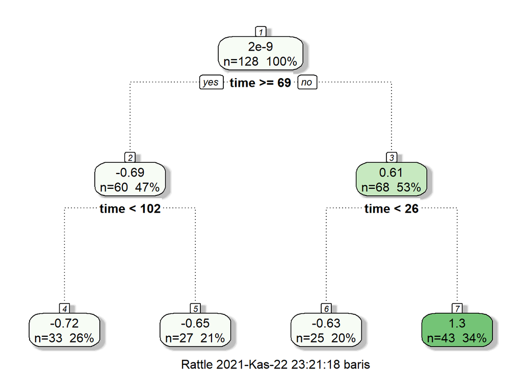

```r
fit3=tree_list[[3]]
fancyRpartPlot(fit3)
```

[figure not shown]

```r
fit4=tree_list[[4]]
fancyRpartPlot(fit4)
```

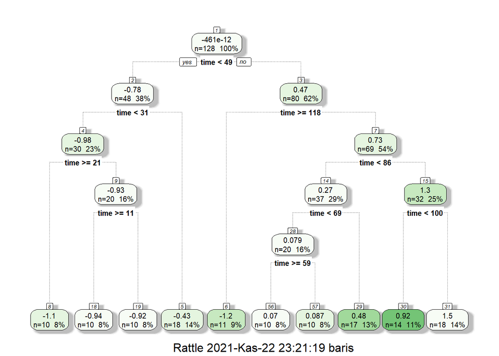

```r
fit5=tree_list[[5]]
fancyRpartPlot(fit5)
```

```r
head(example1,10)
```

```
##     id class time      value
##  1:  1     1    1 -0.4642765
##  2:  1     1    2 -0.5550479
##  3:  1     1    3 -0.8428431
##  4:  1     1    4 -0.8658955
##  5:  1     1    5 -0.9363963
##  6:  1     1    6 -0.8172700
##  7:  1     1    7 -0.2636122
##  8:  1     1    8 -1.2580483
##  9:  1     1    9 -1.2503934
## 10:  1     1   10 -0.9183083
```

```r
head(example2,10)
```

```
##     id class time      value
##  1:  2     1    1 -0.8969721
##  2:  2     1    2 -0.6856855
##  3:  2     1    3 -1.3513818
##  4:  2     1    4 -1.4586668
##  5:  2     1    5 -1.1653456
##  6:  2     1    6 -1.4039293
##  7:  2     1    7 -1.8217996
##  8:  2     1    8 -0.8316011
##  9:  2     1    9 -1.0163124
## 10:  2     1   10 -0.8035304
```

```r
head(example3,10)
```

```
##     id class time       value
##  1:  3     1    1 -0.46469596
##  2:  3     1    2 -0.56773891
##  3:  3     1    3 -0.03202276
##  4:  3     1    4 -0.63504562
##  5:  3     1    5 -0.60282554
##  6:  3     1    6 -0.26685628
##  7:  3     1    7 -0.26706128
##  8:  3     1    8 -0.93104230
##  9:  3     1    9 -0.44938186
## 10:  3     1   10 -0.72134200
```

```r
head(example4,10)
```

```
##     id class time       value
##  1:  4     3    1 -0.18718975
##  2:  4     3    2 -0.62080772
##  3:  4     3    3 -0.81566070
##  4:  4     3    4 -0.52139796
##  5:  4     3    5 -0.79042290
##  6:  4     3    6 -0.96751744
##  7:  4     3    7 -1.48700630
##  8:  4     3    8 -0.27788714
##  9:  4     3    9 -0.83507474
## 10:  4     3   10  0.05059104
```

```r
head(example5,10)
```

```
##     id class time      value
##  1:  5     2    1 -1.1360166
##  2:  5     2    2 -1.3191953
##  3:  5     2    3 -1.8446238
##  4:  5     2    4 -0.7886918
##  5:  5     2    5 -0.2517154
##  6:  5     2    6 -1.4876032
##  7:  5     2    7 -0.6687641
##  8:  5     2    8 -0.3403604
##  9:  5     2    9 -1.0463815
## 10:  5     2   10 -0.3122135
```

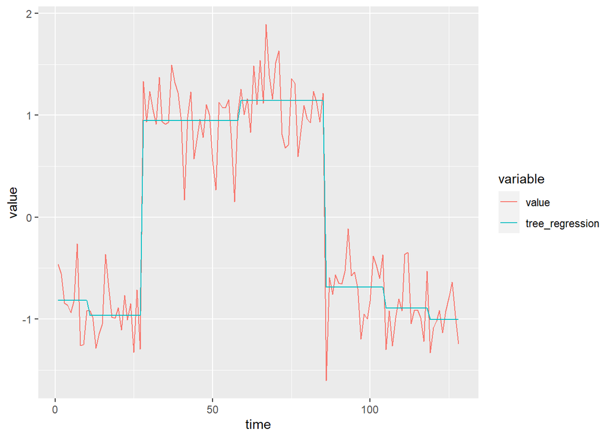

```r
example1[,tree_regression:=predict(tree_list[[1]],example1)]
example2[,tree_regression:=predict(tree_list[[2]],example2)]
example3[,tree_regression:=predict(tree_list[[3]],example3)]
example4[,tree_regression:=predict(tree_list[[4]],example4)]
example5[,tree_regression:=predict(tree_list[[5]],example5)]
melted1=melt(example1,id.vars='time',measure.vars=c('value','tree_regression'))
melted2=melt(example2,id.vars='time',measure.vars=c('value','tree_regression'))
melted3=melt(example3,id.vars='time',measure.vars=c('value','tree_regression'))
melted4=melt(example4,id.vars='time',measure.vars=c('value','tree_regression'))
melted5=melt(example5,id.vars='time',measure.vars=c('value','tree_regression'))
ggplot(melted1,aes(x=time,y=value,color=variable))+geom_line()
```

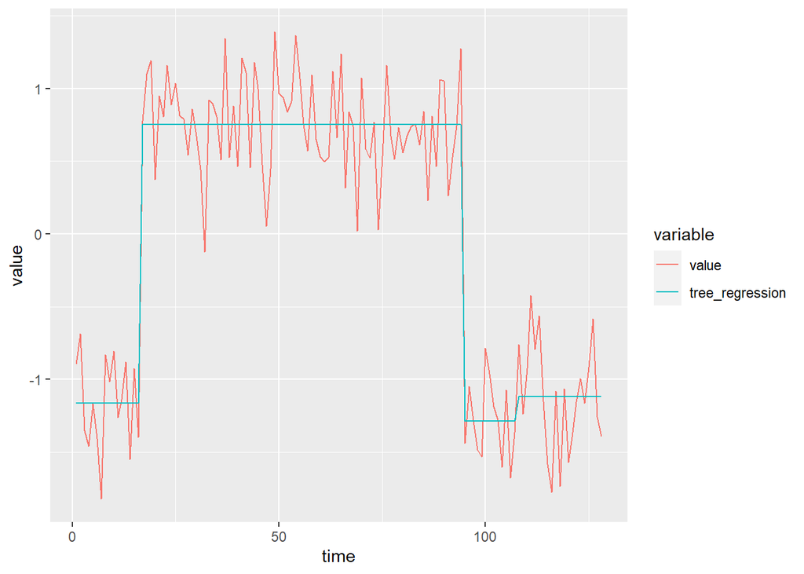

```r
ggplot(melted2,aes(x=time,y=value,color=variable))+geom_line()
```

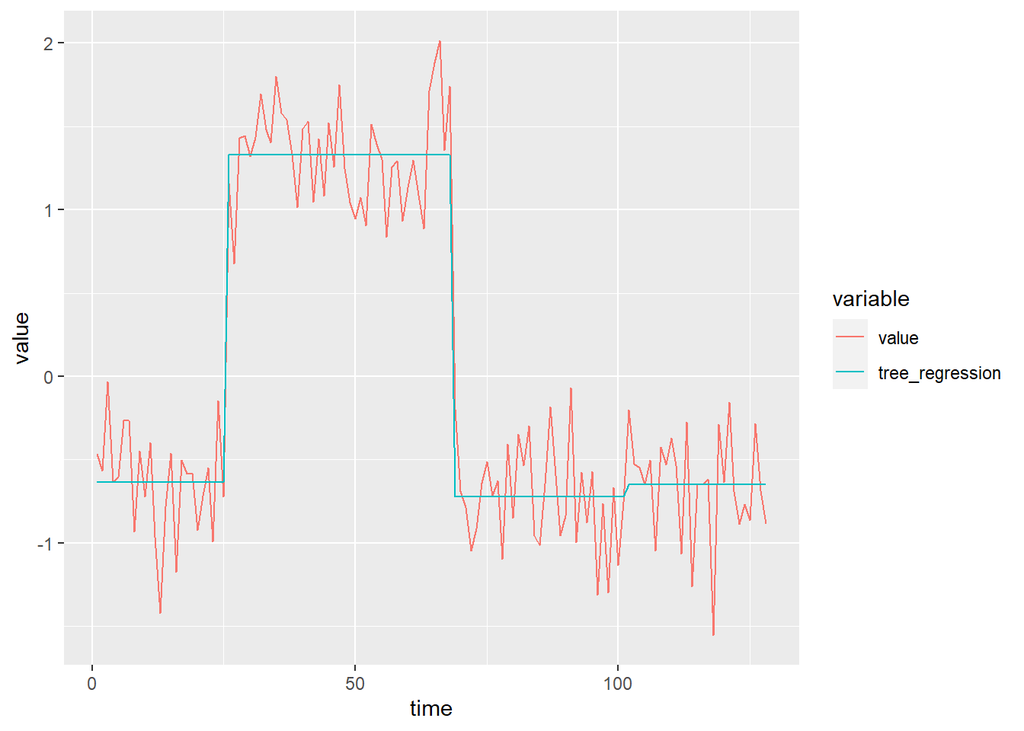

```r
ggplot(melted3,aes(x=time,y=value,color=variable))+geom_line()
```

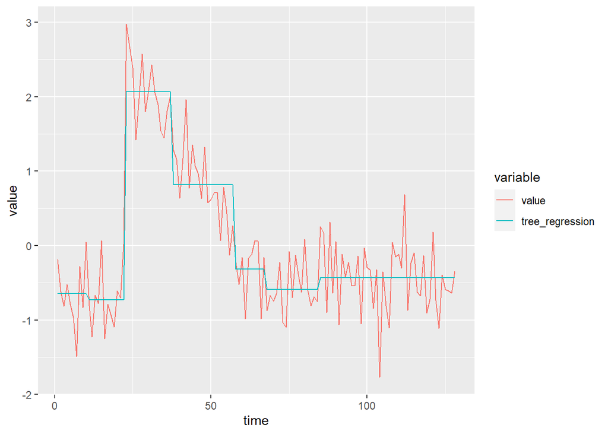

```r
ggplot(melted4,aes(x=time,y=value,color=variable))+geom_line()
```

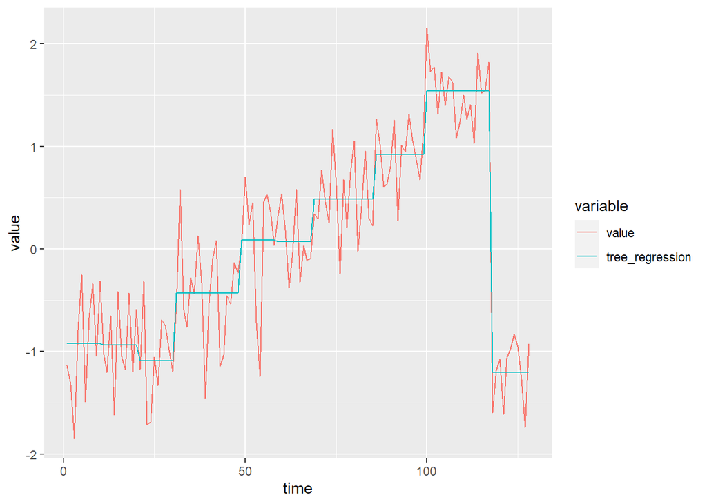

```r
ggplot(melted5,aes(x=time,y=value,color=variable))+geom_line()
```

Above we melted our data to get some better visualization on bell, funnel and cylinder shapes. From the plots, we see that first 3 id values gave us a cylinder shaped plot. 4th id value gave funnel and 5th id value gabe bell shaped plot.

## 3 Comparison of the first two methods

To compare these two methods, we need to find the fused lasso and regression tree values and combine them in one data table. Then we will see the values of fused lasso and regression tree for some of the id values.

```r
fitted=list()
f_mse=list()
t_mse=list()


for(i in 1:30){
    comparison=train_data_1[id==i]
    comparison[,fused_lasso_values:=predict(fused_lasso[[i]],lambda=min_lambda[[i]],comparison)$fit[3:130]]
    comparison[,tree_regression_values:=predict(tree_list[[i]],comparison)]
    fitted[[i]]=comparison

}
head(fitted,10)
```

```
## [[1]]
##      id class time      value fused_lasso_values tree_regression_values
##   1:  1     1    1 -0.4642765        -0.55504787             -0.8172091
##   2:  1     1    2 -0.5550479        -0.74520340             -0.8172091
##   3:  1     1    3 -0.8428431        -0.74520340             -0.8172091
##   4:  1     1    4 -0.8658955        -0.74520340             -0.8172091
##   5:  1     1    5 -0.9363963        -0.74520340             -0.8172091
##  ---
## 124:  1     1  124 -0.9202237        -0.86416422             -1.0040189
## 125:  1     1  125 -0.7893615        -0.86416422             -1.0040189
## 126:  1     1  126 -0.6387058        -0.86416422             -1.0040189
## 127:  1     1  127 -0.9636643        -0.86416422             -1.0040189
## 128:  1     1  128 -1.2451691         0.08896759             -1.0040189
##
## [[2]]
```

[output cut: 124 more lines]

We will calculate the MSE for both methods and we will show the box plot of them. To calculate the MSE values, we used some data manipulations below. We used observed and calculated values to find the MSE for both methods.

```r
fitted1 = do.call(rbind,fitted)
mse_value=melt(fitted1,id.vars=c("id","class","time"),measure.vars=c("value","tree_regression_values","fused_lasso_values"))
mse_value=merge(mse_value,train_data_1[,list(id,class,time,observed=value)],by=c("id","class","time"))
head(mse_value,20)
```

```
##     id class time               variable      value   observed
##  1:  1     1    1                  value -0.4642765 -0.4642765
##  2:  1     1    1 tree_regression_values -0.8172091 -0.4642765
##  3:  1     1    1     fused_lasso_values -0.5550479 -0.4642765
##  4:  1     1    2                  value -0.5550479 -0.5550479
##  5:  1     1    2 tree_regression_values -0.8172091 -0.5550479
##  6:  1     1    2     fused_lasso_values -0.7452034 -0.5550479
##  7:  1     1    3                  value -0.8428431 -0.8428431
##  8:  1     1    3 tree_regression_values -0.8172091 -0.8428431
##  9:  1     1    3     fused_lasso_values -0.7452034 -0.8428431
## 10:  1     1    4                  value -0.8658955 -0.8658955
## 11:  1     1    4 tree_regression_values -0.8172091 -0.8658955
## 12:  1     1    4     fused_lasso_values -0.7452034 -0.8658955
## 13:  1     1    5                  value -0.9363963 -0.9363963
## 14:  1     1    5 tree_regression_values -0.8172091 -0.9363963
## 15:  1     1    5     fused_lasso_values -0.7452034 -0.9363963
## 16:  1     1    6                  value -0.8172700 -0.8172700
## 17:  1     1    6 tree_regression_values -0.8172091 -0.8172700
## 18:  1     1    6     fused_lasso_values -0.7452034 -0.8172700
## 19:  1     1    7                  value -0.2636122 -0.2636122
## 20:  1     1    7 tree_regression_values -0.8172091 -0.2636122
```

```r
mse=mse_value[!(variable=="value"),list(mse_value=mean((value-observed)^2)),list(id,class,variable)]
head(mse,20)
```

```
##     id class               variable  mse_value
##  1:  1     1 tree_regression_values 0.08737098
##  2:  1     1     fused_lasso_values 0.16485770
##  3:  2     1 tree_regression_values 0.10458403
##  4:  2     1     fused_lasso_values 0.21118708
##  5:  3     1 tree_regression_values 0.09406769
##  6:  3     1     fused_lasso_values 0.17519529
##  7:  4     3 tree_regression_values 0.18345079
##  8:  4     3     fused_lasso_values 0.26405710
##  9:  5     2 tree_regression_values 0.15628831
## 10:  5     2     fused_lasso_values 0.39006402
## 11:  6     2 tree_regression_values 0.20689583
## 12:  6     2     fused_lasso_values 0.39698583
## 13:  7     1 tree_regression_values 0.10813201
## 14:  7     1     fused_lasso_values 0.36359543
## 15:  8     3 tree_regression_values 0.18536768
## 16:  8     3     fused_lasso_values 0.55865182
## 17:  9     2 tree_regression_values 0.14170456
## 18:  9     2     fused_lasso_values 0.57333038
## 19: 10     1 tree_regression_values 0.10341226
## 20: 10     1     fused_lasso_values 0.41940371
```

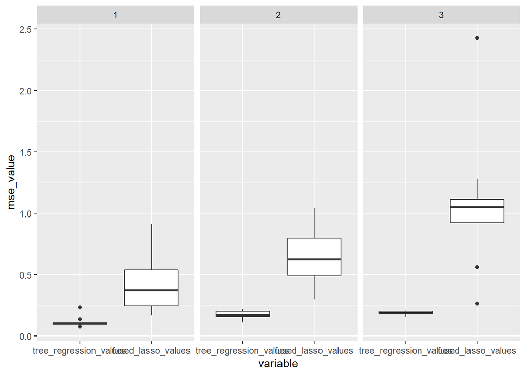

```r
ggplot(mse,aes(x=variable,y=mse_value))+facet_wrap(~class)+geom_boxplot()
```

From the box plots, we see that regression tree has better MSE that means it has lower error than fused lasso method. We can conclude that regression tree method is more useful than fused lasso method.

## 4 Nearest neighbour method

We are asked to use raw time series against our two studied methods above. For this we will calculate the euclidian distances for raw time series, fused lasso method and regression tree method. With diss function, we can calculate the euclidian distances in our created matrices.

```r
train_matrix=as.matrix(train_data[,2:130])
rownames(train_matrix) = train_matrix[,129]
dist=as.matrix(diss(train_matrix,METHOD="EUCL"))
dist[dist==0]=100000
dist_1=apply(dist,2,which.min)
dist_2=apply(dist,2,min)
raw_data=data.frame(series=colnames(dist),nearest_neighbour=rownames(dist)[dist_1],distance=dist_2)
raw_data=merge(raw_data,train_data[,list(nearest_neighbour=id,predicted=class)],by="nearest_neighbour")
raw_data=merge(raw_data,train_data[,list(series=id,actual=class)],by="series")
raw_data$class=ifelse(raw_data$predicted==raw_data$actual,1,0)
head(raw_data,10)
```

```
##    series nearest_neighbour  distance predicted actual class
## 1       1                 2  9.502131         1      1     1
## 2      10                 7  6.810550         1      1     1
## 3      11                12  9.714184         2      2     1
## 4      12                11  9.714184         2      2     1
## 5      13                19 11.471707         1      1     1
## 6      14                 9 10.091123         2      2     1
## 7      15                17  8.239273         2      2     1
## 8      16                19 10.515787         1      3     0
## 9      17                15  8.239273         2      2     1
## 10     18                22  8.588959         2      2     1
```

We will use the same method above to find the euclidian distance in fused lasso method. We want our predicted and actual class values to be the same. We created class column in order to see whether predicted and actual have the same class value.

```r
fus_l=reshape(fitted1[,c("id","time", "fused_lasso_values")],idvar="id",timevar="time",direction="wide")
colnames(fus_l)=gsub("fused_lasso_values","V",names(fus_l))
head(fus_l)
```

```
##    id        V.1        V.2        V.3        V.4        V.5        V.6
## 1:  1 -0.5550479 -0.7452034 -0.7452034 -0.7452034 -0.7452034 -0.7452034
## 2:  2 -0.7913288 -0.9883235 -0.9883235 -0.9883235 -0.9883235 -0.9883235
## 3:  3 -0.4943233 -0.4943233 -0.4943233 -0.4943233 -0.4943233 -0.4943233
## 4:  4 -0.5821848 -0.5821848 -0.5821848 -0.5821848 -0.5821848 -0.5821848
## 5:  5 -0.8802641 -0.8802641 -0.8802641 -0.8802641 -0.8802641 -0.8802641
## 6:  6 -0.3155637 -0.3155637 -0.3155637 -0.3155637 -0.3155637 -0.3155637
##           V.7        V.8        V.9       V.10       V.11       V.12       V.13
## 1: -0.8990842 -0.8990842 -0.8990842 -0.8990842 -0.8990842 -0.8990842 -0.8990842
## 2: -0.9883235 -0.9883235 -0.9883235 -0.9883235 -0.9883235 -0.9883235 -0.9883235
## 3: -0.4943233 -0.4943233 -0.4943233 -0.4943233 -0.4943233 -0.4943233 -0.4943233
## 4: -0.5821848 -0.5821848 -0.5821848 -0.5821848 -0.5821848 -0.5821848 -0.5821848
## 5: -0.8802641 -0.8802641 -0.8802641 -0.8802641 -0.8802641 -0.8802641 -0.8802641
## 6: -0.3155637 -0.3155637 -0.3155637 -0.3155637 -0.3155637 -0.3155637 -0.3155637
##          V.14       V.15       V.16       V.17       V.18       V.19       V.20
```

[output cut: 125 more lines]

```r
train_matrix=as.matrix(fus_l)
rownames(train_matrix)=train_matrix[,1]
dist=as.matrix(diss(train_matrix,METHOD="EUCL"))
dist[dist==0]=1000000
dist_3=apply(dist,2,which.min)
dist_4=apply(dist,2,min)
l_res=data.frame(series=colnames(dist),nearest_neighbour=rownames(dist)[dist_3],distance=dist_4)
l_res=merge(l_res,train_data[,list(nearest_neighbour=id,predicted=class)],by="nearest_neighbour")
l_res=merge(l_res,train_data[,list(series=id,actual=class)],by="series")
l_res$class=ifelse(l_res$predicted==l_res$actual,1,0)
l_res
```

```
##    series nearest_neighbour  distance predicted actual class
## 1       1                 2  7.438780         1      1     1
## 2      10                 7  4.241474         1      1     1
## 3      11                12  4.208127         2      2     1
## 4      12                11  4.208127         2      2     1
## 5      13                15  6.071314         2      1     0
## 6      14                16  6.323254         3      2     0
## 7      15                17  2.284472         2      2     1
## 8      16                14  6.323254         2      3     0
## 9      17                15  2.284472         2      2     1
## 10     18                17  2.331142         2      2     1
## 11     19                18  3.855283         2      1     0
## 12      2                 1  7.438780         1      1     1
## 13     20                16  8.222684         3      3     1
## 14     21                22  5.141181         2      2     1
```

[output cut: 16 more lines]

We will use the same method above to find the euclidian distance in regression tree method. We want our predicted and actual class values to be the same. We created class column in order to see whether predicted and actual have the same class value.

```r
t_regression=reshape(fitted1[,c("id","time","tree_regression_values")],idvar="id",timevar="time",direction="wide")
colnames(t_regression)=gsub("tree_regression_values","V",names(t_regression))
head(t_regression)
```

```
##    id        V.1        V.2        V.3        V.4        V.5        V.6
## 1:  1 -0.8172091 -0.8172091 -0.8172091 -0.8172091 -0.8172091 -0.8172091
## 2:  2 -1.1613113 -1.1613113 -1.1613113 -1.1613113 -1.1613113 -1.1613113
## 3:  3 -0.6339440 -0.6339440 -0.6339440 -0.6339440 -0.6339440 -0.6339440
## 4:  4 -0.6452374 -0.6452374 -0.6452374 -0.6452374 -0.6452374 -0.6452374
## 5:  5 -0.9195566 -0.9195566 -0.9195566 -0.9195566 -0.9195566 -0.9195566
## 6:  6 -0.5593072 -0.5593072 -0.5593072 -0.5593072 -0.5593072 -0.5593072
##           V.7        V.8        V.9       V.10       V.11       V.12       V.13
## 1: -0.8172091 -0.8172091 -0.8172091 -0.8172091 -0.9633528 -0.9633528 -0.9633528
## 2: -1.1613113 -1.1613113 -1.1613113 -1.1613113 -1.1613113 -1.1613113 -1.1613113
## 3: -0.6339440 -0.6339440 -0.6339440 -0.6339440 -0.6339440 -0.6339440 -0.6339440
## 4: -0.6452374 -0.6452374 -0.6452374 -0.6452374 -0.7317436 -0.7317436 -0.7317436
## 5: -0.9195566 -0.9195566 -0.9195566 -0.9195566 -0.9356013 -0.9356013 -0.9356013
## 6: -0.5593072 -0.5593072 -0.5593072 -0.5593072 -0.5593072 -0.5593072 -0.5593072
##          V.14       V.15       V.16       V.17       V.18       V.19       V.20
```

[output cut: 118 more lines]

```r
train_matrix=as.matrix(t_regression)
rownames(train_matrix)=train_matrix[,1]
dist=as.matrix(diss(train_matrix,METHOD="EUCL"))
dist[dist==0]=1000000
dist_5=apply(dist,2,which.min)
dist_6=apply(dist,2,min)
t_res=data.frame(series=colnames(dist),nearest_neighbour=rownames(dist)[dist_5],distance=dist_6)
t_res=merge(t_res,train_data[,list(nearest_neighbour=id,predicted =class)],by="nearest_neighbour")
t_res=merge(t_res,train_data[,list(series=id,actual=class)],by="series")
t_res$class=ifelse(t_res$predicted==t_res$actual,1,0)
t_res
```

```
##    series nearest_neighbour  distance predicted actual class
## 1       1                 2  7.970707         1      1     1
## 2      10                 7  4.565689         1      1     1
## 3      11                12  5.268406         2      2     1
## 4      12                11  5.268406         2      2     1
## 5      13                19  9.271794         1      1     1
## 6      14                 9  7.636176         2      2     1
## 7      15                17  4.788472         2      2     1
## 8      16                19  9.172246         1      3     0
## 9      17                15  4.788472         2      2     1
## 10     18                22  5.400231         2      2     1
## 11     19                23  7.039172         1      1     1
## 12      2                 7  7.176167         1      1     1
## 13     20                25 11.959312         3      3     1
## 14     21                24  9.050421         1      2     0
```

[output cut: 16 more lines]

```r
sum(raw_data$class)/nrow(raw_data)
```

```
## [1] 0.8333333
```

```r
sum(l_res$class)/nrow(l_res)
```

```
## [1] 0.6333333
```

```r
sum(t_res$class)/nrow(t_res)
```

```
## [1] 0.7666667
```

We calculated the accuracy of the three methods and we saw that the accuracy in raw data in best and the accuracy in regression tree method follows it. Fused lasso method has the lowest accuracy among them.

## Conclusion

Normally we expected to find better accuracy values in fused lasso and regression tree methods, but nearest neighbour method gave the best accuracy here. The reason for this occasion may be the high lambda values for some of the id values. By choosing some different id and lambda values we may be able to find better accuracy values for these two methods.